# Nest count estimations and trend for Jamursba-Medi leatherback turtle nesting beaches

This analysis tries to fill in missing nest counts data. A parametric model is fitted to years with complete data. The estimated parameters are used to fill in years without complete data. Ultimately, it aims to look at how the counts are changing over time.

This analysis estimates trends of leatherback turtle nests at two Indonesia nesting beaches (Jamursba-Medi and Wermon) using the annual nest counts. Raw data for the analysis are the recorded number of nests per month. Missing data are imputed using auto-regressive time-series analysis. A few models are used to compare performance of imputation and one with the narrowest prediction (imputation) intervals is used for the final analysis.

# Jamursba-Medi

First, data for Jamursba-Medi are analyzed.

```r
# get JM data first:
data.0.JM <- read.csv('data/JM_nests.csv')
# create regularly spaced time series:
data.2.JM <- data.frame(Year = rep(min(data.0.JM$Year_begin,
                                       na.rm = T):max(data.0.JM$Year_begin,
                                                      na.rm = T),
                                   each = 12),
                        Month_begin = rep(1:12,
                                          max(data.0.JM$Year_begin,
                                              na.rm = T) -
                                            min(data.0.JM$Year_begin,
                                                na.rm = T) + 1)) %>%
  mutate(begin_date = as.Date(paste(Year,
                                    Month_begin,
                                    '01', sep = "-"),
                              format = "%Y-%m-%d"),
         Frac.Year = Year + (Month_begin-0.5)/12) %>%
  select(Year, begin_date, Frac.Year)
# create time-duration filed (in yrs)
# define dates with begin and end dates:
data.0.JM %>% mutate(begin_date = as.Date(paste(Year_begin,
                                                Month_begin,
                                                '01', sep = "-"),
                                          format = "%Y-%m-%d")) %>%
  mutate(end_day = if_else(Month_end.1 == 1 | Month_end.1 == 3 | Month_end.1 == 5 |
                             Month_end.1 == 7 | Month_end.1 == 8 | Month_end.1 == 10 |
                             Month_end.1 == 12, 31,
                           if_else(Month_end.1 == 2,
                                   if_else(leap_year(Year_end) == TRUE,
                                           29, 28), 30))) %>%
  mutate(end_date = as.Date(paste(Year_end, Month_end.1, end_day,
                                  sep = "-"),
                            format = "%Y-%m-%d")) %>%
  mutate(cumu_days = as.numeric(end_date - begin_date[1] + 1),
         num_days = as.numeric(end_date - begin_date) + 1,
         Year = Year_begin,
         Month = Month_begin,
         f_month = as.factor(Month),
         f_year = as.factor(Year),
         Nests = JM.1)   %>%
  select(Year, Month, begin_date,
         end_date, num_days, cumu_days,
         f_month, f_year,
         Nests)  %>%
  na.omit() %>%
  right_join(.,data.2.JM, by = "begin_date") %>%
  reshape::sort_df(.,vars = "Frac.Year") -> data.1.JM
```

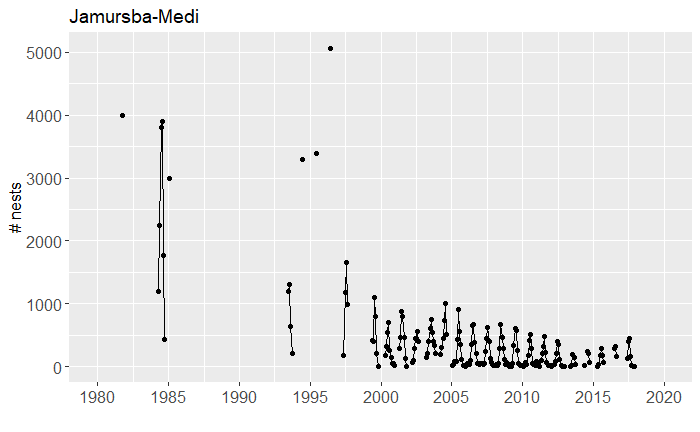

```r
p.JM.all <- ggplot(data.1.JM) +
  geom_point(aes(x = Frac.Year, y = Nests)) +
  geom_line(aes(x = Frac.Year, y = Nests)) +
  scale_x_continuous(breaks = seq(1980, 2020, 5),
                     limits = c(1980, 2020)) +
  labs(x = '', y = '# nests', title = "Jamursba-Medi")  +
  theme(axis.text = element_text(size = 12),
        text = element_text(size = 12))
p.JM.all
```

```r
if (save.fig) ggsave(filename = 'figures/JM_all.png',
                     plot = p.JM.all,
                     dpi = 600, height = 6, width = 8, units = "in")
```

No data were collected in 1998. Since then at least some data were collected within each year. So, we look at the data since 1999:

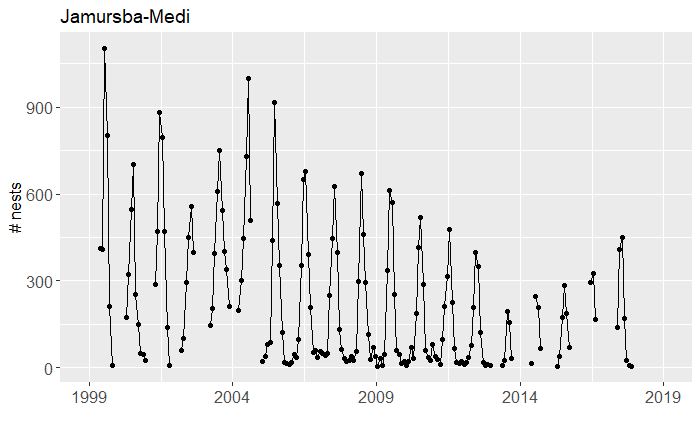

```r
data.1.JM.1999 <- filter(data.1.JM, Year.y > 1998)
p.JM.1999 <- ggplot(data.1.JM.1999) +
  geom_point(aes(x = Frac.Year, y = Nests)) +
  geom_line(aes(x = Frac.Year, y = Nests)) +
  scale_x_continuous(breaks = seq(1999, 2019, 5),
                     limits = c(1999, 2019)) +
  labs(x = '', y = '# nests',
       title = "Jamursba-Medi")  +
  theme(axis.text = element_text(size = 12),
        text = element_text(size = 12))
p.JM.1999
```

```r
if (save.fig) ggsave(filename = 'figures/JM_1999.png',
                     plot = p.JM.1999,
                     dpi = 600, height = 6,
                     width = 8, units = "in")
```

First, I look at the time series in the natural log scle.

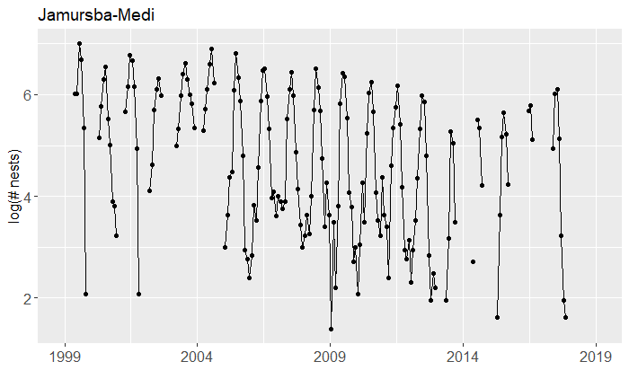

```r
data.1.JM.1999$log_Nests <- log(data.1.JM.1999$Nests)
p.log.JM.1999 <- ggplot(data.1.JM.1999) +
  geom_point(aes(x = Frac.Year, y = log_Nests)) +
  geom_line(aes(x = Frac.Year, y = log_Nests)) +
  scale_x_continuous(breaks = seq(1999, 2019, 5),
                     limits = c(1999, 2019)) +
  labs(x = '', y = 'log(# nests)',
       title = "Jamursba-Medi")  +
  theme(axis.text = element_text(size = 12),
        text = element_text(size = 12))
p.log.JM.1999
```

```r
if (save.fig) ggsave(filename = 'figures/JM_log_1999.png',
                     plot = p.log.JM.1999,
                     dpi = 600, height = 6,
                     width = 8, units = "in")
```

To fill in (or estiamte) the missing data points, we fit a simple auto-regressive model to the data. The analysis was done in a different script and results saved in a .RData file.

```r
load("RData/SSAR1_JM_logN_1999_2018-06-07.RData")
results.JM_SSAR1_logN$jm
```

```
JAGS model:

# simple state space AR1 model for turtle nesting
# https://nwfsc-timeseries.github.io/atsa-labs/sec-jags-uss.html
#
# This uses log normal for logged abundance.

model{
    for (t in 2:T){
        # process
        predX[t] <- theta * X[t-1]
        X[t] ~ dnorm(predX[t], tau.pro)

        # observation
        predY[t] <- X[t]
        y[t] ~ dlnorm(X[t], tau.obs)
    }

    X[1] <- mu
    predY[1] <- X[1]
    y[1] ~ dlnorm(X[1], tau.obs)

    mu ~ dnorm(0, 0.01)
    sigma.pro ~ dunif(0, 200)
    tau.pro <- 1/(sigma.pro * sigma.pro)

    sigma.obs ~ dunif(0, 200)
    tau.obs <- 1/(sigma.obs * sigma.obs)

    theta ~  dnorm(0, 0.01)

}
Fully observed variables:
 T
Partially observed variables:
 y
```

Data used for this analysis:

```r
results.JM_SSAR1_logN$bugs.data
```

```
$`y`
  [1]       NA       NA       NA       NA 6.018593 6.008813 7.005789 6.688355 5.351858 2.079442
 [11]       NA       NA       NA       NA       NA 5.147494 5.771441 6.304449 6.553933 5.529429
 [21] 5.017280 3.891820 3.806662 3.218876       NA       NA       NA 5.662960 6.154858 6.783325
 [31] 6.678342 6.154858 4.941642 2.079442       NA       NA       NA       NA 4.110874 4.624973
 [41] 5.690359 6.109248 6.322565 5.988961       NA       NA       NA       NA       NA       NA
 [51] 4.983607 5.323010 5.981414 6.411818 6.620073 6.297109 5.993961 5.828946 5.351858       NA
 [61]       NA       NA 5.288267 5.710427 6.102559 6.591674 6.907755 6.228511       NA       NA
 [71]       NA       NA 2.995732 3.637586 4.369448 4.477337 6.082219 6.820016 6.338594 5.869297
 [81] 4.795791 2.944439 2.772589 2.397895 2.833213 3.828641 3.526361 4.564348 5.869297 6.480045
 [91] 6.519147 5.966147 5.332719 3.970292 4.094345 3.610918 4.007333 3.891820 3.761200 3.891820
[101] 5.521461 6.104793 6.440947 5.988961 4.875197 4.143135 3.433987 2.995732 3.218876 3.637586
[111] 3.258097 4.007333 5.693732 6.508769 6.133398 5.683580 4.736198 3.401197 4.262680 3.637586
[121] 1.386294 3.496508 2.197225 3.806662 5.820083 6.416732 6.345636 5.533389 4.077537 3.784190
[131] 2.708050 2.995732 2.079442 3.044522 4.262680 3.496508 5.231109 6.028279 6.253829 5.666427
[141] 4.077537 3.526361 3.218876 4.369448 3.637586 3.401197 2.397895 4.595120 5.347108 5.755742
[151] 6.171701 5.420535 4.174387 2.944439 2.772589 3.135494 2.302585 2.944439 3.526361 4.356709
[161] 5.332719 5.983936 5.855072 4.804021 2.833213 1.945910 2.484907 2.197225       NA       NA
[171]       NA       NA 1.945910 3.178054 5.267858 5.043425 3.496508       NA       NA       NA
[181]       NA       NA       NA       NA 2.708050       NA 5.509388 5.342334 4.219508       NA
[191]       NA       NA       NA       NA       NA 1.609438 3.637586 5.164786 5.652489 5.225747
[201] 4.234107       NA       NA       NA       NA       NA       NA       NA       NA 5.683580
[211] 5.786897 5.111988       NA       NA       NA       NA       NA       NA       NA       NA
[221] 4.941642 6.008813 6.109248 5.129899 3.218876 1.945910 1.609438       NA

$T
[1] 228
```

The MCMC run converged fine according to the Gelman diagnostic.

```r
results.JM_SSAR1_logN$g.diag
```

```
Potential scale reduction factors:

          Point est. Upper C.I.
mu              1.00       1.00
sigma.obs       1.05       1.16
sigma.pro       1.00       1.01
theta           1.00       1.00

Multivariate psrf

1.04
```

Visual inspection of convergence of the process parameters. They all look good, except sigma.obs.

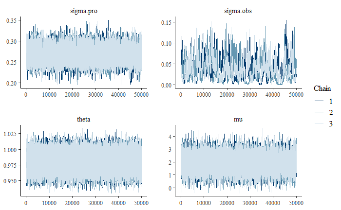

```r
zm.JM.logN.1999 <- results.JM_SSAR1_logN$zm
mcmc_trace(zm.JM.logN.1999,
           c("sigma.pro", "sigma.obs",
             "theta", "mu"))
```

Shows in density plots too.

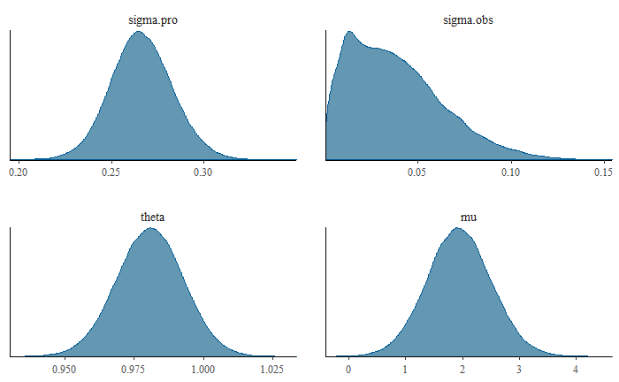

```r
mcmc_dens(zm.JM.logN.1999,
           c("sigma.pro", "sigma.obs",
             "theta", "mu"))
```

I look at the predicted values as a time-series plot. Red is the estimated missing values and green are observed counts. 5 and 95% confidence limits are shown in dashed line. Although I called mode_X, they should have been median_X because they were 50 percentiles… oops.

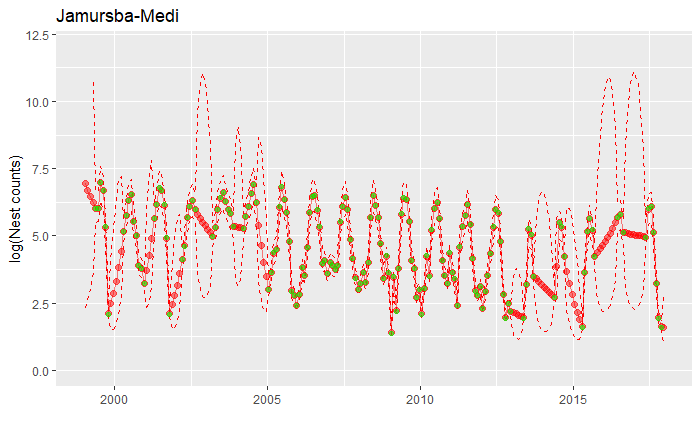

```r
Xs.stats <- results.JM_SSAR1_logN$Xs.stats
ys.stats <- results.JM_SSAR1_logN$ys.stats
ys.stats$log_obsY <- log(results.JM_SSAR1_logN$data.1$Nests)
p.JM.logN.predicted.1999 <- ggplot() +
  #geom_point(data = ys.stats,
  #           aes(x = time, y = mode_y), color = "blue") +
  #geom_line(data = Xs.stats,
  #          aes(x = time, y = mode_X), color = 'blue') +
  geom_line(data = Xs.stats,
            aes(x = time, y = exp(high_X)), color = "red",
            linetype = 2) +
  geom_point(data = Xs.stats,
             aes(x = time, y = exp(mode_X)), color = "red",
             alpha = 0.5, size = 2) +
  geom_line(data = Xs.stats,
            aes(x = time, y = exp(mode_X)), color = "red",
            alpha = 0.5) +
  geom_line(data = Xs.stats,
            aes(x = time, y = exp(low_X)), color = "red",
            linetype = 2) +
  geom_point(data = ys.stats,
             aes(x = time, y = log_obsY),
             color = "green",
             alpha = 0.5) +
  scale_y_continuous(limits = c(0, 12)) +
  labs(x = '', y = "log(Nest counts)",
       title = "Jamursba-Medi")
p.JM.logN.predicted.1999
```

```r
if (save.fig) ggsave(filename = 'figures/JM_logN_predicted_1999.png',
                     plot = p.JM.logN.predicted.1999,
                     dpi = 600, height = 6,
                     width = 8, units = "in")
```

The missing values are basically linearly interpolated between observed values. That is not very useful. Converting them back into the non-log scale:

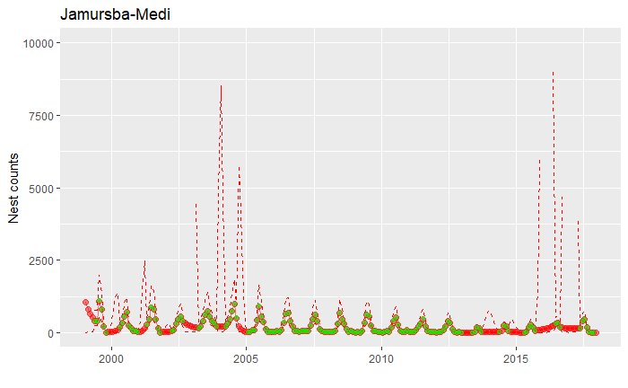

```r
p.JM.N.predicted.1999 <- ggplot() +
  #geom_point(data = ys.stats,
  #           aes(x = time, y = mode_y), color = "blue") +
  #geom_line(data = Xs.stats,
  #          aes(x = time, y = mode_X), color = 'blue') +
  geom_line(data = Xs.stats,
            aes(x = time, y = exp(exp(high_X))), color = "red",
            linetype = 2) +
  geom_point(data = Xs.stats,
             aes(x = time, y = exp(exp(mode_X))), color = "red",
             alpha = 0.5, size = 2) +
  geom_line(data = Xs.stats,
            aes(x = time, y = exp(exp(mode_X))), color = "red",
            alpha = 0.5) +
  geom_line(data = Xs.stats,
            aes(x = time, y = exp(exp(low_X))), color = "red",
            linetype = 2) +
  geom_point(data = ys.stats,
             aes(x = time, y = obsY),
             color = "green",
             alpha = 0.5) +
  scale_y_continuous(limits = c(0, 10000)) +
  labs(x = '', y = "Nest counts",
       title = "Jamursba-Medi")
p.JM.N.predicted.1999
```

The upper bound is not useful… So, looking at these in the log space may not be helpful. I think the change in variance of nest counts between summer and winter is an important biological signal and should be modeled. The variability is obvious when the observed nest counts are plotted monthly:

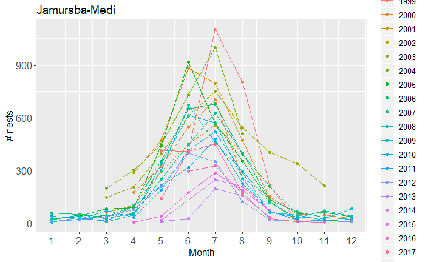

```r
p.JM.monthly.1999 <- ggplot(data.1.JM.1999) +
  geom_point(aes(x = Month, y = Nests, color = f_year)) +
  geom_line(aes(x = Month, y = Nests, color = f_year)) +
  scale_x_continuous(breaks = seq(1, 12, 1)) +
  labs(x = 'Month', y = '# nests',
       title = "Jamursba-Medi", color = "Year")  +
  theme(axis.text = element_text(size = 12),
        text = element_text(size = 12))
#        legend.position = c(0.9, 0.6))
p.JM.monthly.1999
```

```r
if (save.fig) ggsave(filename = 'figures/JM_monthly_1999.png',
                     plot = p.JM.monthly.1999,
                     dpi = 600, height = 6,
                     width = 8, units = "in")
```

Using the cyclic nature of nesting, we should be able to fit a model to fill in the missing data points. We need to make some assumptions about how data were collected, unless we have a measure of effort every year. I ran time-series models to compare how they do in terms of filling in the missing data points.

First, I try to fill in the missing data points using an AR(1) state-space model and data since 1999. JAGS model for this analysis:

```r
load("RData/SSAR1_month_var_JM_1999_2018-06-15.RData")
results.JM_SSAR1_month_var$jm
```

```
JAGS model:

# simple state space AR1 model for turtle nesting
# original code from Lab 7, Introduction to Bayesian Time-Series
# analysis using Jags. Univ Washington:
# https://www.scribd.com/document/373707632/Lab-7-Fitting-models-with-JAGS-pdf

# Also can be found here:
# https://nwfsc-timeseries.github.io/atsa-labs/sec-jags-uss.html

model{
    for (t in 2:T){
        # process
        predX[t] <- theta * X[t-1]

        tau.pro[t] <- ifelse(m[t] < 10 && m[t] > 4, tau.pro1, tau.pro2)
        X[t] ~ dnorm(predX[t], tau.pro[t])T(0,)

        # observation
        predY[t] <- X[t]
        y[t] ~ dnorm(X[t], tau.obs)
    }

    X[1] <- mu
    predY[1] <- X[1]
    y[1] ~ dnorm(X[1], tau.obs)T(0,)

    mu ~ dnorm(0, 0.01)
    sigma.pro1 ~ dunif(0, 1500)
    tau.pro1 <- 1/(sigma.pro1 * sigma.pro1)

    sigma.pro2 ~ dunif(0, 100)
    tau.pro2 <- 1/(sigma.pro2 * sigma.pro2)

    sigma.obs ~ dunif(0, 500)
    tau.obs <- 1/(sigma.obs * sigma.obs)

    theta ~  dnorm(0, 10)
}
Fully observed variables:
 T m
Partially observed variables:
 y
```

It has two process standard deviations; one for summer (May through September; sigma.pro1) and another for winter (sigma.pro2). Observation has one standard deviation under the assumption that it does not change with time. Data for this analysis is here: y is the observed nest counts, m is months, and T is the duration of the time series. NAs indicate missing data points.

```r
results.JM_SSAR1_month_var$bugs.data
```

```
$`y`
  [1]   NA   NA   NA   NA  411  407 1103  803  211    8   NA   NA   NA   NA   NA  172  321  547  702
 [20]  252  151   49   45   25   NA   NA   NA  288  471  883  795  471  140    8   NA   NA   NA   NA
 [39]   61  102  296  450  557  399   NA   NA   NA   NA   NA   NA  146  205  396  609  750  543  401
 [58]  340  211   NA   NA   NA  198  302  447  729 1000  507   NA   NA   NA   NA   20   38   79   88
 [77]  438  916  566  354  121   19   16   11   17   46   34   96  354  652  678  390  207   53   60
 [96]   37   55   49   43   49  250  448  627  399  131   63   31   20   25   38   26   55  297  671
[115]  461  294  114   30   71   38    4   33    9   45  337  612  570  253   59   44   15   20    8
[134]   21   71   33  187  415  520  289   59   34   25   79   38   30   11   99  210  316  479  226
[153]   65   19   16   23   10   19   34   78  207  397  349  122   17    7   12    9   NA   NA   NA
[172]   NA    7   24  194  155   33   NA   NA   NA   NA   NA   NA   NA   15   NA  247  209   68   NA
[191]   NA   NA   NA   NA   NA    5   38  175  285  186   69   NA   NA   NA   NA   NA   NA   NA   NA
[210]  294  326  166   NA   NA   NA   NA   NA   NA   NA   NA  140  407  450  169   25    7    5   NA

$m
  [1]  1  2  3  4  5  6  7  8  9 10 11 12  1  2  3  4  5  6  7  8  9 10 11 12  1  2  3  4  5  6  7  8
 [33]  9 10 11 12  1  2  3  4  5  6  7  8  9 10 11 12  1  2  3  4  5  6  7  8  9 10 11 12  1  2  3  4
 [65]  5  6  7  8  9 10 11 12  1  2  3  4  5  6  7  8  9 10 11 12  1  2  3  4  5  6  7  8  9 10 11 12
 [97]  1  2  3  4  5  6  7  8  9 10 11 12  1  2  3  4  5  6  7  8  9 10 11 12  1  2  3  4  5  6  7  8
[129]  9 10 11 12  1  2  3  4  5  6  7  8  9 10 11 12  1  2  3  4  5  6  7  8  9 10 11 12  1  2  3  4
[161]  5  6  7  8  9 10 11 12  1  2  3  4  5  6  7  8  9 10 11 12  1  2  3  4  5  6  7  8  9 10 11 12
[193]  1  2  3  4  5  6  7  8  9 10 11 12  1  2  3  4  5  6  7  8  9 10 11 12  1  2  3  4  5  6  7  8
[225]  9 10 11 12

$T
[1] 228
```

Convergence seemed to reach, according to the Gelman diagnostic.

```r
results.JM_SSAR1_month_var$g.diag
```

```
Potential scale reduction factors:

           Point est. Upper C.I.
mu               1.00       1.00
sigma.obs        1.02       1.06
sigma.pro1       1.00       1.00
sigma.pro2       1.00       1.00
theta            1.00       1.00

Multivariate psrf

1.01
```

Posterior trace plots also show the same results. sigma.obs (standard deviation of observations) doesn’t look great in the trace.

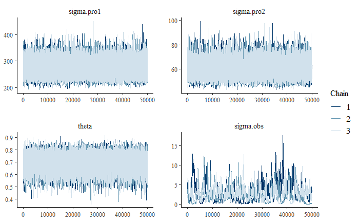

```r
zm.var.JM.1999 <- results.JM_SSAR1_month_var$zm
mcmc_trace(zm.var.JM.1999,
           c("sigma.pro1", "sigma.pro2",
             "theta", "sigma.obs"))
```

Posterior density plots of the same parameters show the same thing about sigma.obs. Note that these are very small numbers.

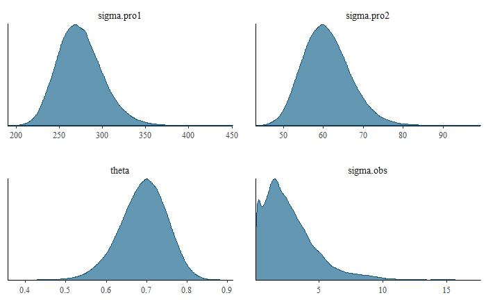

```r
zm.var.JM.1999 <- results.JM_SSAR1_month_var$zm
mcmc_dens(zm.var.JM.1999,
          c("sigma.pro1", "sigma.pro2",
            "theta", "sigma.obs"))
```

Predicted missing values from this model:

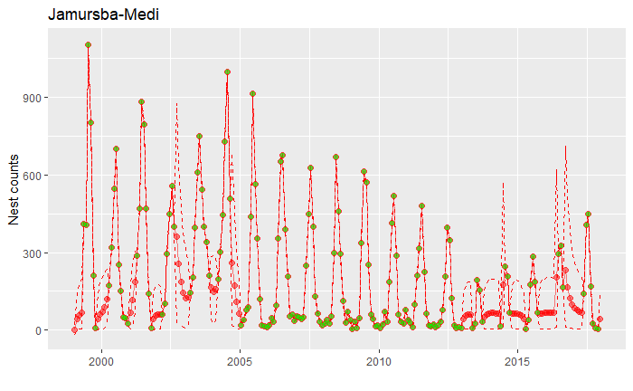

```r
Xs.stats <- results.JM_SSAR1_month_var$Xs.stats
ys.stats <- results.JM_SSAR1_month_var$ys.stats
p.JM.month_var.predicted.1999 <- ggplot() +
  #geom_point(data = ys.stats,
  #           aes(x = time, y = mode_y), color = "blue") +
  #geom_line(data = Xs.stats,
  #          aes(x = time, y = mode_X), color = 'blue') +
  geom_line(data = Xs.stats,
            aes(x = time, y = high_X), color = "red",
            linetype = 2) +
  geom_point(data = Xs.stats,
             aes(x = time, y = median_X), color = "red",
             alpha = 0.5, size = 2) +
  geom_line(data = Xs.stats,
            aes(x = time, y = median_X), color = "red",
            alpha = 0.5) +
  geom_line(data = Xs.stats,
            aes(x = time, y = low_X), color = "red",
            linetype = 2) +
  geom_point(data = ys.stats,
             aes(x = time, y = obsY),
             color = "green",
             alpha = 0.5) +
  #scale_y_continuous(limits = c(0, 5000)) +
  labs(x = '', y = "Nest counts",
       title = "Jamursba-Medi")
p.JM.month_var.predicted.1999
```

```r
if (save.fig) ggsave(filename = 'figures/JM_month_var_predicted_1999.png',
                     plot = p.JM.logN.predicted.1999,
                     dpi = 600, height = 6,
                     width = 8, units = "in")
```

Visually, it looks a lot better than the previous model (log) but it still is basically interpolating missing values. Confidence intervals are much better though.

```r
dif.Xy_all <- sum((na.omit(Xs.stats$median_X -
                                 ys.stats$obsY))^2)
dif.Xy_all
```

```
[1] 0.1145499
```

The sum of squared differences between observed and predicted is `0.115` where there were `164` data points. This is a very small difference, scary small!

The next model has two variances and two “slope” parameters. As before, two variances correspond to nesting (May, June, July, August, and September; sigma.pro1) and non-nesting (sigma.pro2) seasons, whereas two slopes are for increasing (Jan to Jul) and decreasing (Aug to Dec) phases of each year.

```r
load("RData/SSAR1_month_JM_var_theta_1999_2018-06-14.RData")
results.JM_SSAR1_month_var_theta$jm
```

```
JAGS model:

# simple state space AR1 model for turtle nesting
# original code from Lab 7, Introduction to Bayesian Time-Series
# analysis using Jags. Univ Washington:
# https://www.scribd.com/document/373707632/Lab-7-Fitting-models-with-JAGS-pdf

# Also can be found here:
# https://nwfsc-timeseries.github.io/atsa-labs/sec-jags-uss.html
#
# For this model, I added another theta. Two thetas are used for increasing
# and decreasing months within each year.

model{
    for (t in 2:T){
        # process: increasing before August, decreasing after July
        theta[t] <- ifelse(m[t] < 8, theta.1, theta.2)
        predX[t] <- theta[t] * X[t-1]

        # one variance for May - Sep, another for the rest
        tau.pro[t] <- ifelse(m[t] < 10 && m[t] > 4, tau.pro1, tau.pro2)
        X[t] ~ dnorm(predX[t], tau.pro[t])T(0,)

        # observation
        predY[t] <- X[t]
        y[t] ~ dnorm(X[t], tau.obs)
    }

    X[1] <- mu
    predY[1] <- X[1]
    y[1] ~ dnorm(X[1], tau.obs)T(0,)

    mu ~ dnorm(0, 0.01)
    sigma.pro1 ~ dunif(0, 600)
    tau.pro1 <- 1/(sigma.pro1 * sigma.pro1)

    sigma.pro2 ~ dunif(0, 100)
    tau.pro2 <- 1/(sigma.pro2 * sigma.pro2)

    sigma.obs ~ dunif(0, 500)
    tau.obs <- 1/(sigma.obs * sigma.obs)

    theta.1 ~ dnorm(0, 10)
    theta.2 ~ dnorm(0, 10)
}
Fully observed variables:
 T m
Partially observed variables:
 y
```

Data used for this analysis should be the same as the last one:

```r
results.JM_SSAR1_month_var_theta$bugs.data
```

```
$`y`
  [1]   NA   NA   NA   NA  411  407 1103  803  211    8   NA   NA   NA   NA   NA  172  321  547  702
 [20]  252  151   49   45   25   NA   NA   NA  288  471  883  795  471  140    8   NA   NA   NA   NA
 [39]   61  102  296  450  557  399   NA   NA   NA   NA   NA   NA  146  205  396  609  750  543  401
 [58]  340  211   NA   NA   NA  198  302  447  729 1000  507   NA   NA   NA   NA   20   38   79   88
 [77]  438  916  566  354  121   19   16   11   17   46   34   96  354  652  678  390  207   53   60
 [96]   37   55   49   43   49  250  448  627  399  131   63   31   20   25   38   26   55  297  671
[115]  461  294  114   30   71   38    4   33    9   45  337  612  570  253   59   44   15   20    8
[134]   21   71   33  187  415  520  289   59   34   25   79   38   30   11   99  210  316  479  226
[153]   65   19   16   23   10   19   34   78  207  397  349  122   17    7   12    9   NA   NA   NA
[172]   NA    7   24  194  155   33   NA   NA   NA   NA   NA   NA   NA   15   NA  247  209   68   NA
[191]   NA   NA   NA   NA   NA    5   38  175  285  186   69   NA   NA   NA   NA   NA   NA   NA   NA
[210]  294  326  166   NA   NA   NA   NA   NA   NA   NA   NA  140  407  450  169   25    7    5   NA

$m
  [1]  1  2  3  4  5  6  7  8  9 10 11 12  1  2  3  4  5  6  7  8  9 10 11 12  1  2  3  4  5  6  7  8
 [33]  9 10 11 12  1  2  3  4  5  6  7  8  9 10 11 12  1  2  3  4  5  6  7  8  9 10 11 12  1  2  3  4
 [65]  5  6  7  8  9 10 11 12  1  2  3  4  5  6  7  8  9 10 11 12  1  2  3  4  5  6  7  8  9 10 11 12
 [97]  1  2  3  4  5  6  7  8  9 10 11 12  1  2  3  4  5  6  7  8  9 10 11 12  1  2  3  4  5  6  7  8
[129]  9 10 11 12  1  2  3  4  5  6  7  8  9 10 11 12  1  2  3  4  5  6  7  8  9 10 11 12  1  2  3  4
[161]  5  6  7  8  9 10 11 12  1  2  3  4  5  6  7  8  9 10 11 12  1  2  3  4  5  6  7  8  9 10 11 12
[193]  1  2  3  4  5  6  7  8  9 10 11 12  1  2  3  4  5  6  7  8  9 10 11 12  1  2  3  4  5  6  7  8
[225]  9 10 11 12

$T
[1] 228
```

The MCMC run converged fine according to the Gelman diagnostic.

```r
results.JM_SSAR1_month_var_theta$g.diag
```

```
Potential scale reduction factors:

           Point est. Upper C.I.
mu               1.00       1.00
sigma.obs        1.01       1.03
sigma.pro1       1.00       1.00
sigma.pro2       1.00       1.00
theta.1          1.00       1.00
theta.2          1.00       1.00

Multivariate psrf

1.01
```

Visual inspection of convergence of the process parameters. They all look good.

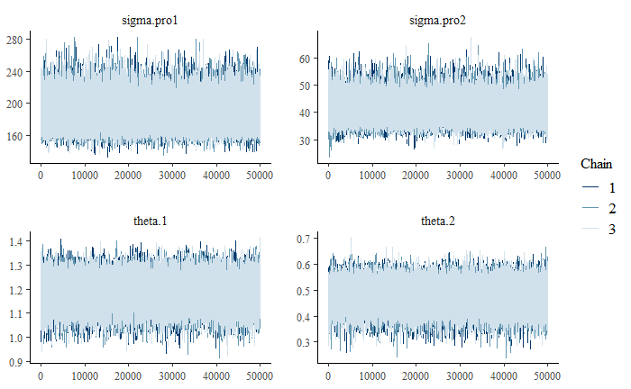

```r
zm.var.theta.JM.1999 <- results.JM_SSAR1_month_var_theta$zm
mcmc_trace(zm.var.theta.JM.1999,
           c("sigma.pro1", "sigma.pro2",
             "theta.1", "theta.2"))
```

The observation variance parameter did not converge well.

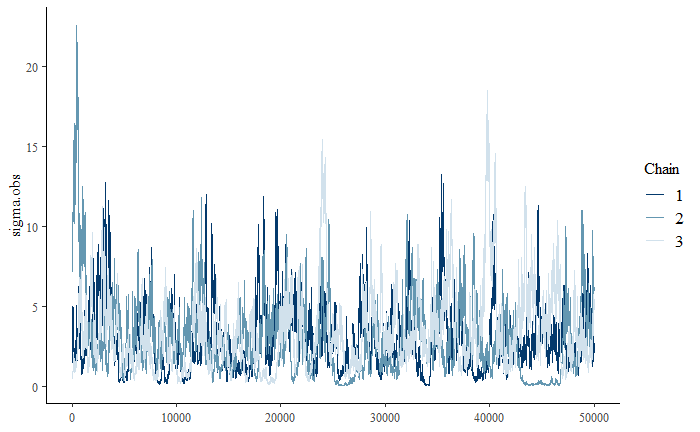

```r
mcmc_trace(zm.var.theta.JM.1999, "sigma.obs")
```

Shows in density plot too.

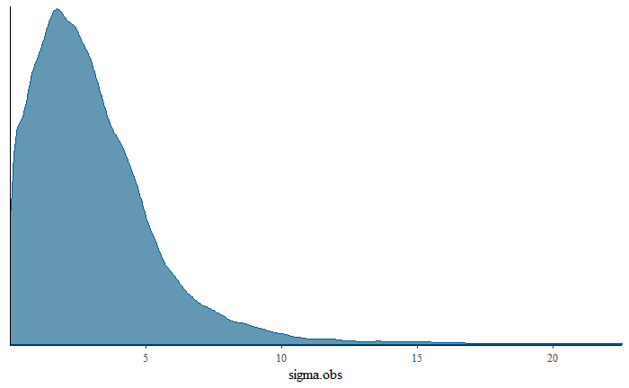

```r
mcmc_dens(zm.var.theta.JM.1999,
          "sigma.obs")
```

I look at the predicted values as a time-series plot. Red is the estimated missing values and green are observed counts. 5 and 95% confidence limits are shown in dashed line.

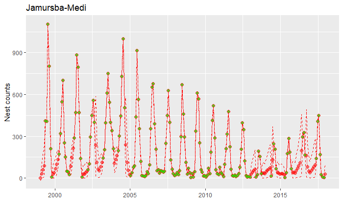

```r
Xs.stats_var_theta <- results.JM_SSAR1_month_var_theta$Xs.stats
ys.stats_var_theta <- results.JM_SSAR1_month_var_theta$ys.stats
ys.stats_var_theta$obsY <- results.JM_SSAR1_month_var_theta$data.1$Nests
p.JM.predicted_month_var_theta_1999 <- ggplot() +
  #geom_point(data = ys.stats,
  #           aes(x = time, y = mode_y), color = "blue") +
  #geom_line(data = Xs.stats,
  #          aes(x = time, y = mode_X), color = 'blue') +
  geom_line(data = Xs.stats_var_theta,
            aes(x = time, y = high_X), color = "red",
            linetype = 2) +
  geom_point(data = Xs.stats_var_theta,
             aes(x = time, y = median_X), color = "red",
             alpha = 0.5, size = 2) +
  geom_line(data = Xs.stats_var_theta,
            aes(x = time, y = median_X), color = "red",
            alpha = 0.5) +
  geom_line(data = Xs.stats_var_theta,
            aes(x = time, y = low_X), color = "red",
            linetype = 2) +
  geom_point(data = ys.stats_var_theta,
             aes(x = time, y = obsY), color = "green",
             alpha = 0.5) +
  labs(x = '', y = "Nest counts",
       title = "Jamursba-Medi")
p.JM.predicted_month_var_theta_1999
```

```r
if (save.fig) ggsave(filename = 'figures/JM_predicted_month_var_theta_1999.png',
                     plot = p.JM.predicted_month_var_theta_1999,
                     dpi = 600, height = 6,
                     width = 8, units = "in")
```

The uncertainty shrunk quite a bit with this model.

```r
dif.Xy_var_theta <- sum((na.omit(Xs.stats_var_theta$median_X -
                                 ys.stats_var_theta$obsY))^2)
dif.Xy_var_theta
```

```
[1] 1.150882
```

The sum of squared differences between observed and predicted is `1.15` where there were `164` data points.

A bit larger than the last one but still a very small difference, scary small! I like the smaller credible intervals with this model. So, for now, I’m going to use the output from this one.

Sum within each year to find change in trend over the years.

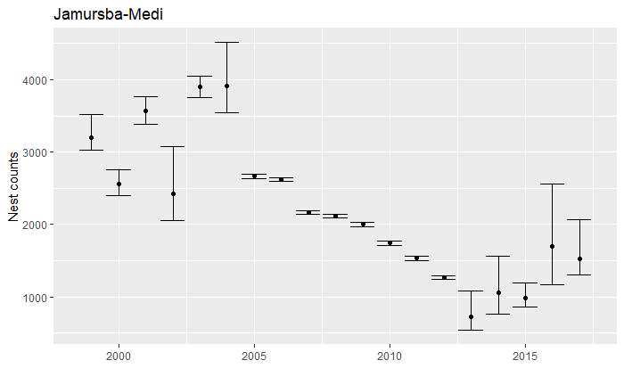

```r
#sum.posterior is in Dc_Indonesia_nesting_fcn.R
yrs <- as.matrix(c(min(ys.stats_var_theta$year):max(ys.stats_var_theta$year)))
X.posteriors.all <- lapply(apply(yrs,
                                 MARGIN = 1,
                                 FUN = sum.posterior,
                                 Xs.stats = Xs.stats_var_theta,
                                 zm = zm.var.theta.JM.1999),
                           FUN = function(x) rowSums(x$samples))
Xs.year <- as.data.frame(matrix(unlist(lapply(X.posteriors.all,
                                              FUN = quantile,
                                              c(0.025, 0.5, 0.975))),
                                ncol = 3, byrow = T))
colnames(Xs.year) <- c("low", "total", "high")
Xs.year <-mutate(Xs.year,
                 year = c(min(ys.stats_var_theta$year):max(ys.stats_var_theta$year)))
# Xs.stats %>% #mutate(f.year = as.factor(year)) %>%
#   group_by(year) %>% summarise(total = sum(mode_X),
#                                low = sum(low_X),
#                                high = sum(high_X)) -> Xs.year
p.JM.estimated.counts <- ggplot(Xs.year) +
  geom_point(aes(x = year, y = total))+
  geom_errorbar(aes(x = year, ymin = low, ymax = high)) +
  labs(title = 'Jamursba-Medi', x = '', y = "Nest counts")
if (save.fig) ggsave(filename = 'figures/JM_estimated_counts.png',
                     plot = p.JM.estimated.counts,
                     dpi = 600, height = 6,
                     width = 8, units = "in")
p.JM.estimated.counts
```

Adding the earlier year’s data as just sum of counts:

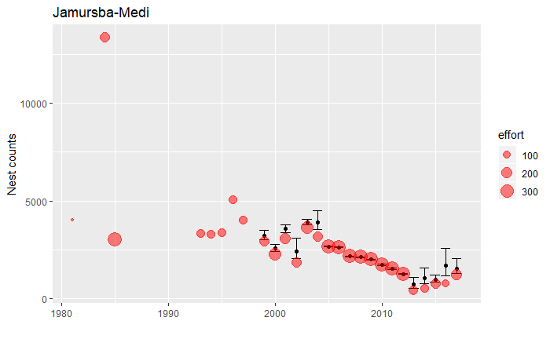

```r
data.1.JM %>% group_by(Year.y) %>%
  summarise(sum_Nests = sum(Nests, na.rm = T),
            year = mean(Year.y, na.rm = T),
            effort = sum(num_days, na.rm = T))%>%
  filter(effort > 0) -> data.1.JM.ByYear
p.JM.estimated.observed <- p.JM.estimated.counts +
  geom_point(data = data.1.JM.ByYear,
             aes(x = year, y = sum_Nests, size = effort),
             color = "red", alpha = 0.5)
p.JM.estimated.observed
```

The size of circles indicates effort in the number of sampling days.

# Winter vs. Summer nest trends

Because of the nearshore currents are different between summer and winter, it may make more sense to look at trends for winter and summer counts separately. So, we have to pull in the predicted numbers from model outputs. First from Wermon. The “best” model and dataset combination was two-tau one-theta with May not included in the summer counts.

```r
# get Wermon output
load("RData/SSAR1_month_W_2006_2018-06-12.RData")
zm.W <- results.Warmon_SSAR1_month_2006$zm
Xs.stats.W <- results.Warmon_SSAR1_month_2006$Xs.stats
ys.stats.W <- results.Warmon_SSAR1_month_2006$ys.stats
# for this analysis, we need to extract just summer/winter numbers.
yrs.W <- as.matrix(c(min(Xs.stats.W$year):max(Xs.stats.W$year)))
# summer is May through September
X.posteriors.all.W.summer <- lapply(apply(yrs.W,
                                          MARGIN = 1,
                                          FUN = sum.posterior,
                                          months = c(5:9),
                                          Xs.stats = Xs.stats.W,
                                          zm = zm.W),
                                    FUN = function(x) rowSums(x$samples))
Xs.year.W.summer <- as.data.frame(matrix(unlist(lapply(X.posteriors.all.W.summer,
                                                       FUN = quantile,
                                                       c(0.025, 0.5, 0.975))),
                                         ncol = 3, byrow = T))
colnames(Xs.year.W.summer) <- c("low", "total", "high")
Xs.year.W.summer <- mutate(Xs.year.W.summer,
                           year = c(min(Xs.stats.W$year):max(Xs.stats.W$year)))
# winter is Jan-Apr and October-Dece
X.posteriors.all.W.winter <- lapply(apply(yrs.W,
                                          MARGIN = 1,
                                          FUN = sum.posterior,
                                          months = c(1:4, 10:12),
                                          Xs.stats = Xs.stats.W,
                                          zm = zm.W),
                                    FUN = function(x) rowSums(x$samples))
Xs.year.W.winter <- as.data.frame(matrix(unlist(lapply(X.posteriors.all.W.winter,
                                                       FUN = quantile,
                                                       c(0.025, 0.5, 0.975))),
                                         ncol = 3, byrow = T))
colnames(Xs.year.W.winter) <- c("low", "total", "high")
Xs.year.W.winter <- mutate(Xs.year.W.winter,
                           year = c(min(Xs.stats.W$year):max(Xs.stats.W$year)))
```

Next is Jamursba-Medi:

```r
load("RData/SSAR1_month_JM_var_theta_1999_2018-06-14.RData")
zm.JM <- results.JM_SSAR1_month_var_theta$zm
Xs.stats.JM <- results.JM_SSAR1_month_var_theta$Xs.stats
ys.stats.JM <- results.JM_SSAR1_month_var_theta$ys.stats
# for this analysis, we need to extract just summer/winter numbers.
yrs.JM <- as.matrix(c(min(Xs.stats.JM$year):max(Xs.stats.JM$year)))
# summer is May through September
X.posteriors.all.JM.summer <- lapply(apply(yrs.JM,
                                           MARGIN = 1,
                                           FUN = sum.posterior,
                                           months = c(5:9),
                                           Xs.stats = Xs.stats.JM,
                                           zm = zm.JM),
                                     FUN = function(x) rowSums(x$samples))
Xs.year.JM.summer <- as.data.frame(matrix(unlist(lapply(X.posteriors.all.JM.summer,
                                                        FUN = quantile,
                                                        c(0.025, 0.5, 0.975))),
                                          ncol = 3, byrow = T))
colnames(Xs.year.JM.summer) <- c("low", "total", "high")
Xs.year.JM.summer <- mutate(Xs.year.JM.summer,
                            year = c(min(Xs.stats.JM$year):max(Xs.stats.JM$year)))
# winter is Jan-Apr and October-Dece
X.posteriors.all.JM.winter <- lapply(apply(yrs.JM,
                                           MARGIN = 1,
                                           FUN = sum.posterior,
                                           months = c(1:4, 10:12),
                                           Xs.stats = Xs.stats.JM,
                                           zm = zm.JM),
                                     FUN = function(x) rowSums(x$samples))
Xs.year.JM.winter <- as.data.frame(matrix(unlist(lapply(X.posteriors.all.JM.winter,
                                                        FUN = quantile,
                                                        c(0.025, 0.5, 0.975))),
                                          ncol = 3, byrow = T))
colnames(Xs.year.JM.winter) <- c("low", "total", "high")
Xs.year.JM.winter <- mutate(Xs.year.JM.winter,
                            year = c(min(Xs.stats.JM$year):max(Xs.stats.JM$year)))
```

Then combine them together. If there was no data in either location (NA), I put zero, which probably is not kosher…

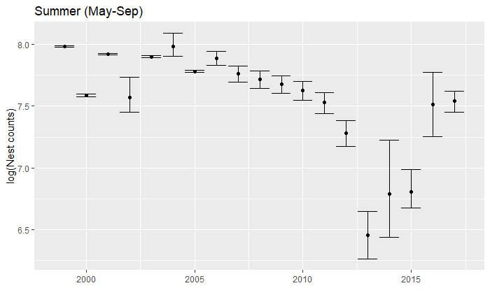

```r
Xs.year.JM.summer %>% full_join(Xs.year.W.summer, by = "year") %>%
  transmute(year = year,
            low = low.x + ifelse(is.na(low.y), 0, low.y),
            total = total.x + ifelse(is.na(total.y), 0, total.y),
            high = high.x + ifelse(is.na(high.y), 0, high.y)) -> Xs.year.summer
p.summer.log <- ggplot(data = Xs.year.summer) +
  geom_point(aes(x = year, y = log(total)))+
  geom_errorbar(aes(x = year, ymin = log(low), ymax = log(high))) +
  labs(title = 'Summer (May-Sep)', x = '', y = "log(Nest counts)")
if (save.fig) ggsave(filename = 'figures/summer_JMandW_log.png',
                     plot = p.summer.log,
                     dpi = 600, height = 6,
                     width = 8, units = "in")
p.summer.log
```

In non-log scale:

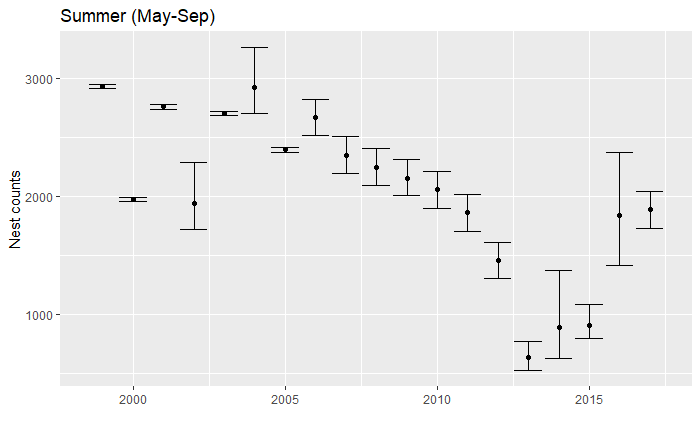

```r
p.summer <- ggplot(data = Xs.year.summer) +
  geom_point(aes(x = year, y = total))+
  geom_errorbar(aes(x = year, ymin = low, ymax = high)) +
  labs(title = 'Summer (May-Sep)', x = '', y = "Nest counts")
if (save.fig) ggsave(filename = 'figures/summer_JMandW.png',
                     plot = p.summer.log,
                     dpi = 600, height = 6,
                     width = 8, units = "in")
p.summer
```

Even in the non-log scale, the increase in the last five years seems obvious… How do we capture this for predicting the future trend?

Fit a GAM:

```r
Xs.year.summer %>% mutate(year.0 = year - min(year)) -> Xs.year.summer
fit.gam.summer <- gam(total ~ s(year.0),
                      data = Xs.year.summer)
sum.gam.summer <- summary(fit.gam.summer)
sum.gam.summer
```

```
Family: gaussian
Link function: identity

Formula:
total ~ s(year.0)

Parametric coefficients:
            Estimate Std. Error t value Pr(>|t|)
(Intercept)  2029.45      74.01   27.42 1.82e-12 ***
---
Signif. codes:  0 ‘***’ 0.001 ‘**’ 0.01 ‘*’ 0.05 ‘.’ 0.1 ‘ ’ 1

Approximate significance of smooth terms:
           edf Ref.df    F  p-value
s(year.0) 5.61  6.755 9.43 0.000152 ***
---
Signif. codes:  0 ‘***’ 0.001 ‘**’ 0.01 ‘*’ 0.05 ‘.’ 0.1 ‘ ’ 1

R-sq.(adj) =  0.773   Deviance explained = 84.4%
GCV = 1.5961e+05  Scale est. = 1.0408e+05  n = 19
```

Then make the response curve.

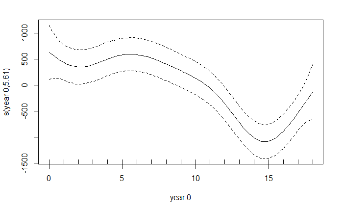

```r
gam.val.summer <- plot(fit.gam.summer)
```

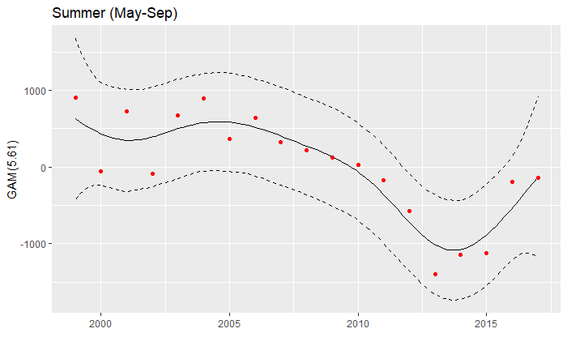

```r
gam.val.summer.df <- data.frame(x = gam.val.summer[[1]]$x,
                                fit = gam.val.summer[[1]]$fit,
                                se = gam.val.summer[[1]]$se)
Xs.year.summer %>%
  mutate(log.total = log(total)) %>%
  mutate(log.total.std = log(total) - mean(log(total), na.rm = T)) %>%
  mutate(total.std = total - mean(total, na.rm = T)) -> Xs.year.summer3
p.summer.GAM <- ggplot() +
  geom_line(data = gam.val.summer.df,
            aes(x = x+min(Xs.year.summer$year),
                y = fit)) +
  geom_line(data = gam.val.summer.df,
            aes(x = x+min(Xs.year.summer$year),
                y = fit + 2*se), linetype = 2) +
  geom_line(data = gam.val.summer.df,
            aes(x = x+min(Xs.year.summer$year),
                y = fit - 2*se), linetype = 2) +
  geom_point(data = Xs.year.summer3,
             aes(x = year, y = total.std),
             color = 'red') +
  labs(title = 'Summer (May-Sep)', x = '',
       y = paste0('GAM(', signif(sum.gam.summer$edf, digits = 3), ')'))

if (save.fig) ggsave(filename = 'figures/summer_GAM.png',
                     plot = p.summer.GAM,
                     dpi = 600, height = 6,
                     width = 8, units = "in")
p.summer.GAM
```

Note that trying to extrapolate the “trend” into the future is not useful because the prediction is depending on what we have observed in the past. What have others done? The green turtle SRT approach was not useful because it just created trajectories based on estimated growth rate and its uncertainty.

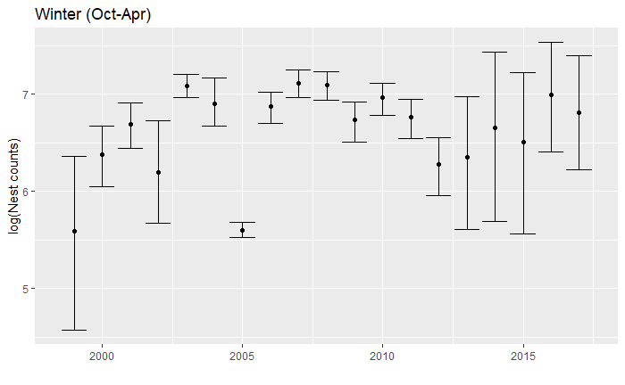

```r
Xs.year.JM.winter %>% full_join(Xs.year.W.winter, by = "year") %>%
  transmute(year = year,
            low = low.x + ifelse(is.na(low.y), 0, low.y),
            total = total.x + ifelse(is.na(total.y), 0, total.y),
            high = high.x + ifelse(is.na(high.y), 0, high.y)) -> Xs.year.winter
p.winter.log <- ggplot(data = Xs.year.winter) +
  geom_point(aes(x = year, y = log(total)))+
  geom_errorbar(aes(x = year,
                    ymin = log(low),
                    ymax = log(high))) +
  labs(title = 'Winter (Oct-Apr)', x = '',
       y = "log(Nest counts)")
if (save.fig) ggsave(filename = 'figures/winter_JMandW_log.png',
                     plot = p.winter.log,
                     dpi = 600, height = 6,
                     width = 8, units = "in")
p.winter.log
```

In non-log scale:

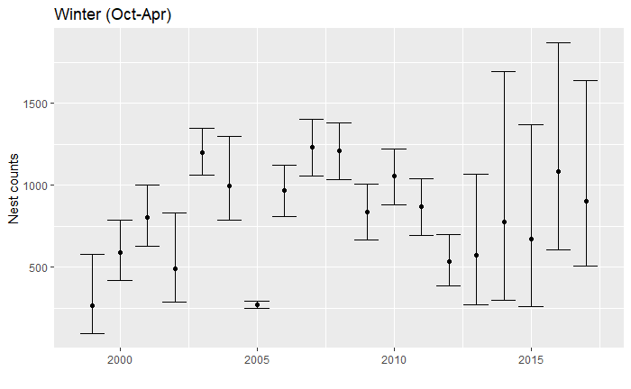

```r
p.winter <- ggplot(data = Xs.year.winter) +
  geom_point(aes(x = year, y = total))+
  geom_errorbar(aes(x = year,
                    ymin = low,
                    ymax = high)) +
  labs(title = 'Winter (Oct-Apr)', x = '',
       y = "Nest counts")
if (save.fig) ggsave(filename = 'figures/winter_JMandW.png',
                     plot = p.summer.log,
                     dpi = 600, height = 6,
                     width = 8, units = "in")
p.winter
```

Fit a GAM:

```r
Xs.year.winter %>% mutate(year.0 = year - min(year)) -> Xs.year.winter
fit.gam.winter <- gam(total ~ s(year.0),
                      data = Xs.year.winter)
sum.gam.winter <- summary(fit.gam.winter)
sum.gam.winter
```

```
Family: gaussian
Link function: identity

Formula:
total ~ s(year.0)

Parametric coefficients:
            Estimate Std. Error t value Pr(>|t|)
(Intercept)   807.81      61.64   13.11 1.05e-09 ***
---
Signif. codes:  0 ‘***’ 0.001 ‘**’ 0.01 ‘*’ 0.05 ‘.’ 0.1 ‘ ’ 1

Approximate significance of smooth terms:
            edf Ref.df     F p-value
s(year.0) 2.756  3.429 1.383   0.254

R-sq.(adj) =  0.181   Deviance explained = 30.7%
GCV =  89974  Scale est. = 72187     n = 19
```

Then make the response curve.

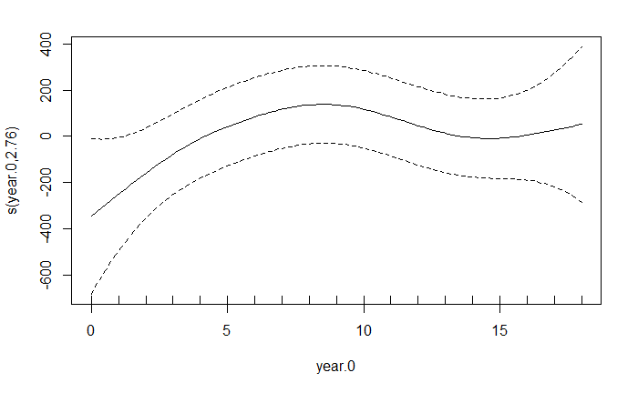

```r
gam.val.winter <- plot(fit.gam.winter)
```

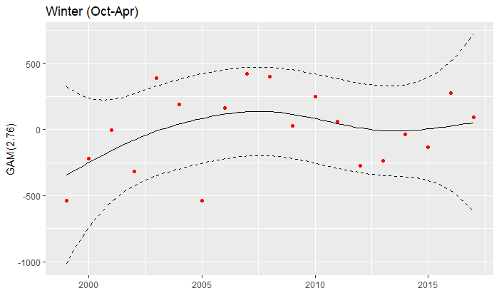

```r
gam.val.winter.df <- data.frame(x = gam.val.winter[[1]]$x,
                                fit = gam.val.winter[[1]]$fit,
                                se = gam.val.winter[[1]]$se)
Xs.year.winter %>%
  mutate(log.total = log(total)) %>%
  mutate(log.total.std = log(total) - mean(log(total), na.rm = T)) %>%
  mutate(total.std = total - mean(total, na.rm = T)) -> Xs.year.winter3
p.winter.GAM <- ggplot() +
  geom_line(data = gam.val.winter.df,
            aes(x = x+min(Xs.year.summer$year),
                y = fit)) +
  geom_line(data = gam.val.winter.df,
            aes(x = x+min(Xs.year.summer$year),
                y = fit + 2*se), linetype = 2) +
  geom_line(data = gam.val.winter.df,
            aes(x = x+min(Xs.year.summer$year),
                y = fit - 2*se), linetype = 2) +
  geom_point(data = Xs.year.winter3,
             aes(x = year, y = total.std),
             color = 'red') +
  labs(title = 'Winter (Oct-Apr)', x = '',
       y = paste0('GAM(', signif(sum.gam.winter$edf, digits = 3), ')'))

if (save.fig) ggsave(filename = 'figures/winter_GAM.png',
                     plot = p.winter.GAM,
                     dpi = 600, height = 6,
                     width = 8, units = "in")
p.winter.GAM
```